# Day 3

## More charts per plot

```r
housing$price_percent=housing$MEDV/mean(housing$MEDV)*100
housing$rm_percent=housing$RM/mean(housing$RM)*100
head(housing)
```

```
##      CRIM ZN INDUS CHAS   NOX    RM  AGE    DIS RAD TAX PTRATIO      B LSTAT MEDV price_percent rm_percent
## 1 0.00632 18  2.31    0 0.538 6.575 65.2 4.0900   1 296    15.3 396.90  4.98 24.0     106.51137   104.6202
## 2 0.02731  0  7.07    0 0.469 6.421 78.9 4.9671   2 242    17.8 396.90  9.14 21.6      95.86023   102.1698
## 3 0.02729  0  7.07    0 0.469 7.185 61.1 4.9671   2 242    17.8 392.83  4.03 34.7     153.99768   114.3265
## 4 0.03237  0  2.18    0 0.458 6.998 45.8 6.0622   3 222    18.7 394.63  2.94 33.4     148.22832   111.3509
## 5 0.06905  0  2.18    0 0.458 7.147 54.2 6.0622   3 222    18.7 396.90  5.33 36.2     160.65464   113.7218
## 6 0.02985  0  2.18    0 0.458 6.430 58.7 6.0622   3 222    18.7 394.12  5.21 28.7     127.36984   102.3130
```

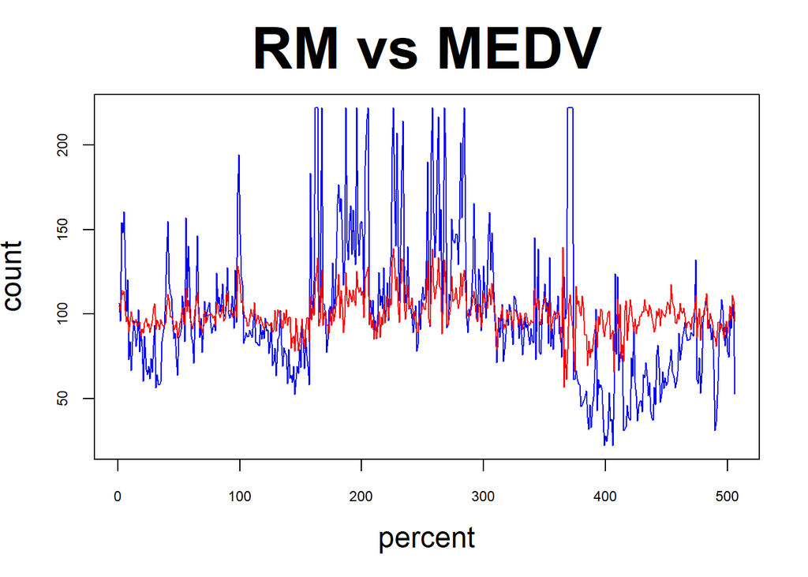

```r
plot(housing$price_percent, type="l",,main="RM vs MEDV",xlab= "percent",ylab = "count",cex.main=3, cex.lab=1.5, cex.axis=0.75,col="blue")
lines(housing$rm_percent, type="l",,main="RM vs MEDV",xlab= "percent",ylab = "count",cex.main=3, cex.lab=1.5, cex.axis=0.75, col="red")
```

## **Pie Chart**

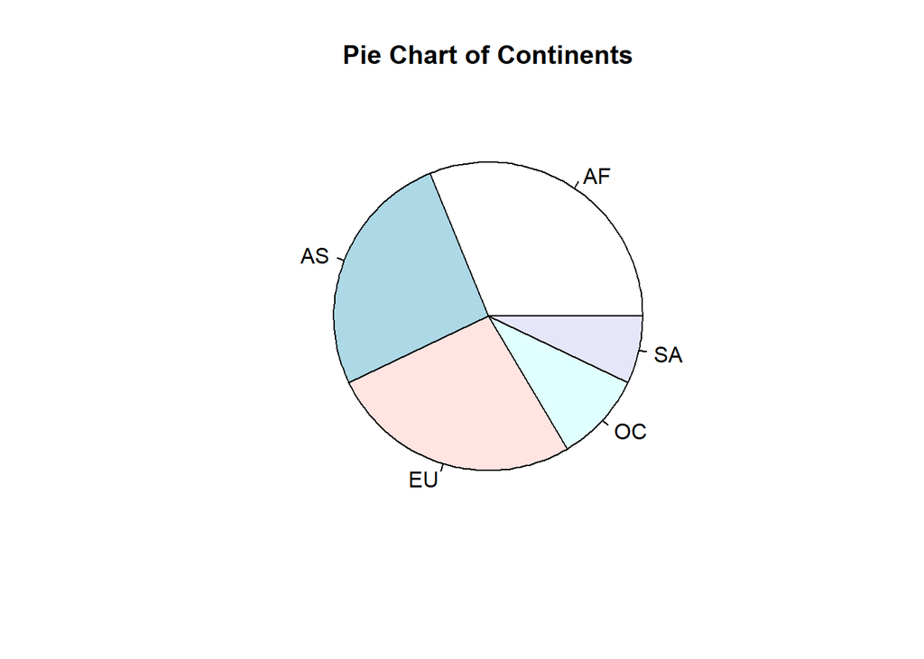

```r
pie(continent_counts, main="Pie Chart of Continents")
```

## [**CheatSheet of Styles**](http://publish.illinois.edu/johnrgallagher/files/2015/10/BaseGraphicsCheatsheet.pdf)

## Histograms

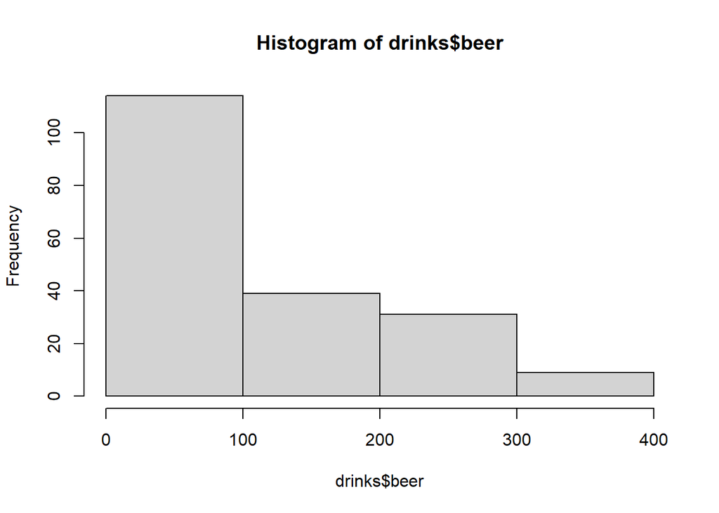

```r
hist(drinks$beer,breaks = 5)
```

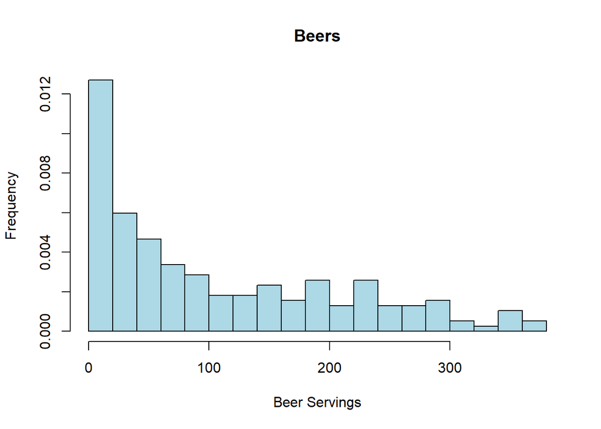

```r
hist(drinks$beer, breaks = 20, col = "lightblue", main = "Beers", xlab = "Beer Servings", ylab="Frequency",prob=TRUE)
```

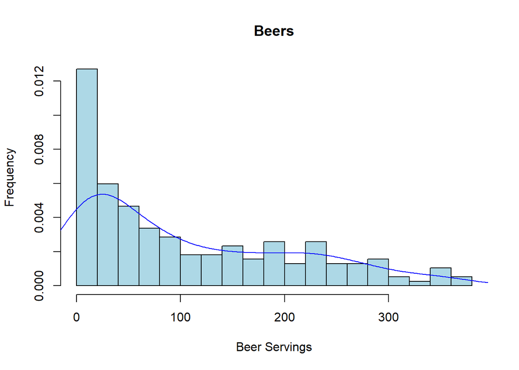

```r
# Compare with density plot (smooth version of a histogram).
hist(drinks$beer, breaks = 20, col = "lightblue", main = "Beers", xlab = "Beer Servings", ylab="Frequency",prob=TRUE)
lines(density(drinks$beer), col = "blue") #lwd: thickness
```

**Challenge: Create a histogram with hist for using `MEDV` in the housing data.**

- Set the bins to 20.

For data sets with a small number of observations, the stripchart function is a good choice

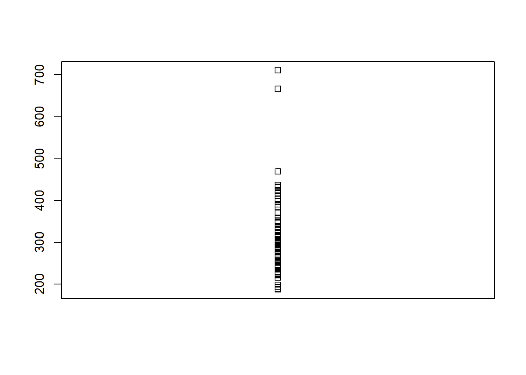

```r
stripchart(housing$TAX,vertical = TRUE)
```

plot a response for multiple levels of a factor

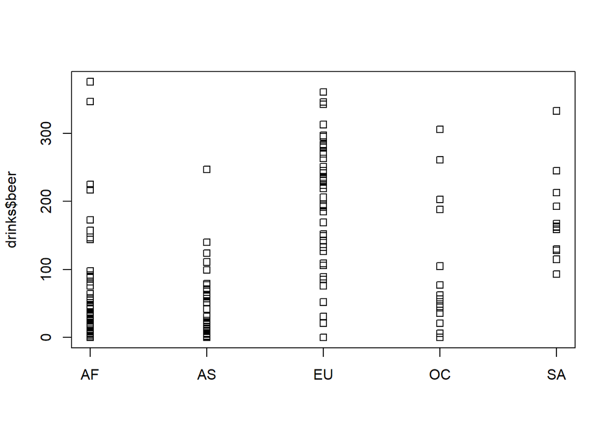

```r
stripchart(drinks$beer~drinks$continent, data = housing, vertical = TRUE)
```

### Boxplot:

We can use boxplots to quickly summarize distributions.

**Five-number summary:**

- min = minimum value
- 25% = first quartile (Q1) = median of the lower half of the data
- 50% = second quartile (Q2) = median of the data
- 75% = third quartile (Q3) = median of the upper half of the data
- max = maximum value

(It’s more useful than mean and standard deviation for describing skewed distributions.)

**Interquartile Range (IQR)** = Q3 - Q1

**Outliers:**

- below Q1 - 1.5 * IQR
- above Q3 + 1.5 * IQR

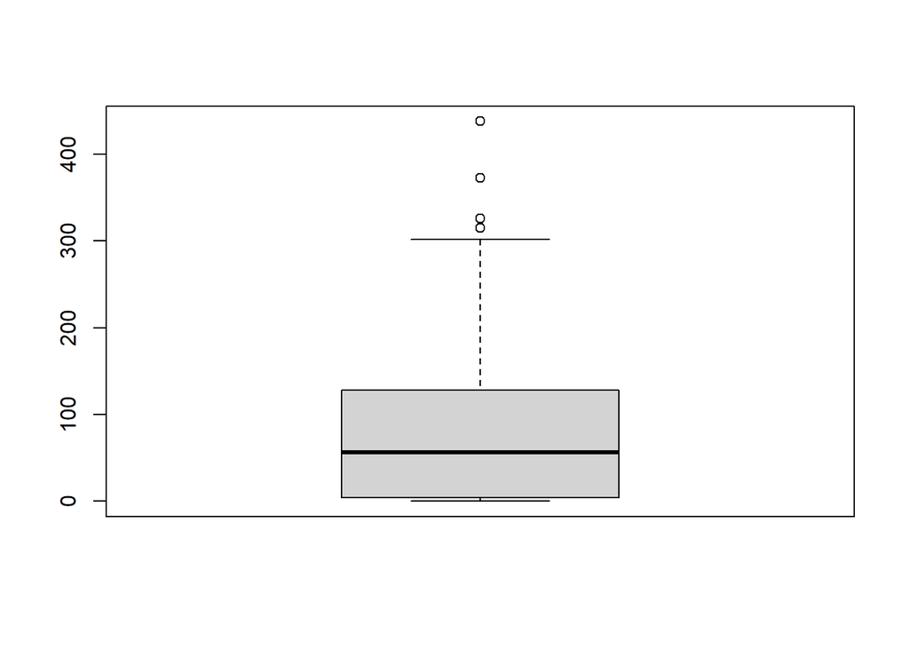

```r
boxplot(drinks$spirit, data = drinks)
```

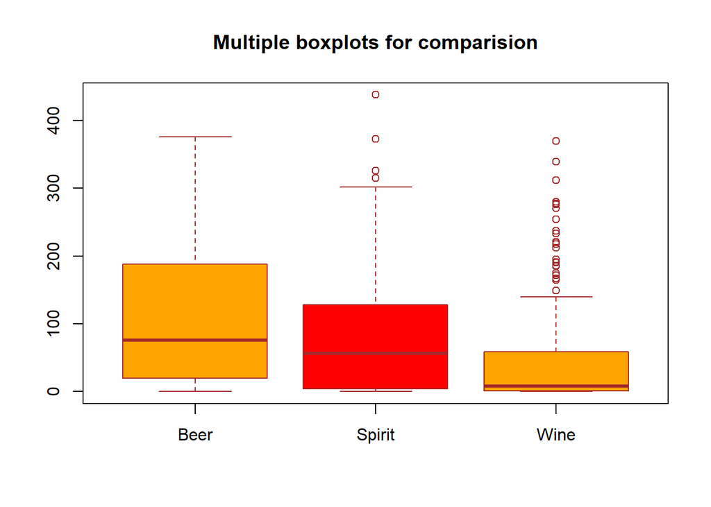

```r
boxplot(drinks$beer, drinks$spirit, drinks$wine,
main = "Multiple boxplots for comparision",
names = c("Beer", "Spirit", "Wine"),
col = c("orange","red"),
border = "brown"
)
```

**EXTRA:**

Beanplots may be a more informative alternative to boxplots.

```
#install.packages("beanplot")

library(beanplot)
beanplot(drinks$beer~drinks$continent, data = housing)
```

[figure not shown]

# ggplot2 Package

- One of the most popular libraries in R.
- There are four main parts of a basic ggplot2 visualization: the `ggplot()` function, the `data` parameter, the `aes()` function, and the geom.

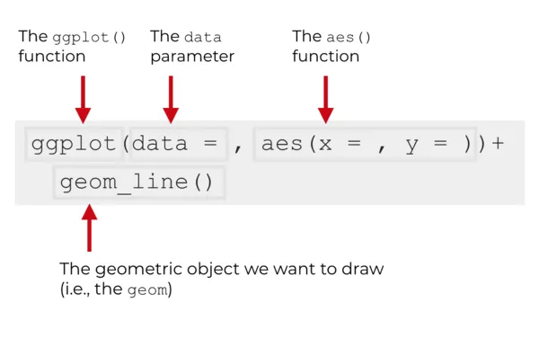

- The `ggplot()` function is the core function of ggplot2. It initiates plotting.
- Almost everything else in the ggplot2 system is built “on top of” this function
- The `data` parameter essentially specifies the data that you want to visualize. The ggplot2 system works almost exclusively with `data.frame` objects.
- “Geoms” are the geometric objects of a data visualization: Lines, points, and bars are all types of “geoms.”
  - If you want to make a line chart, the “geom” will be “line geom”. You can draw line geoms with the `geom_line()` function.
- Different GEOMS have different attributes
  - For example point geoms have attributes like color, size, x-position, and y-position.
- So there’s a dataset that you will plot, and then there’s the visual output itself, which is determined by your geom specification.
- There needs to be a *connection* between the data (the dataframe) and the visual objects that we draw (the geoms).
  - The AES function creates the mappings from data to geoms. The `aes()` function enables you to create a set of “mappings” from your dataset to the geoms in your data visualization.

## **Line chart using ggplot2:**

- Let’s say that you want to plot *line* geoms.
- Essentially, you want to create a line chart. So imagine you want to put `Drinks$beers` on the x axis and `drinks$liters`on the y axis.

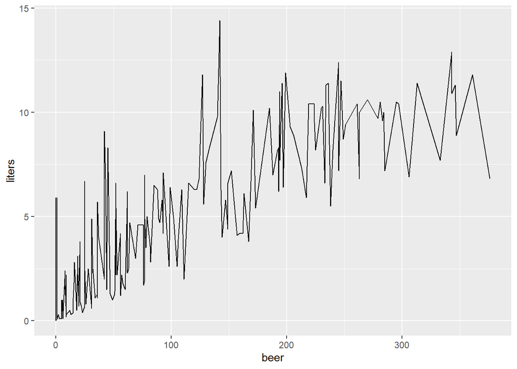

```r
library(ggplot2)
ggplot(data = drinks, aes(x = beer, y = liters)) + geom_line()
```

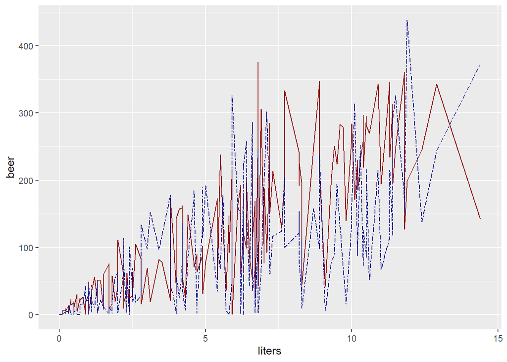

```r
library(ggplot2)
ggplot(drinks, aes(x=liters)) +
  geom_line(aes(y = beer), color = "darkred") +
  geom_line(aes(y = spirit), color="darkblue", linetype="twodash")
```

Now, I want to draw scatterplot for the same data:

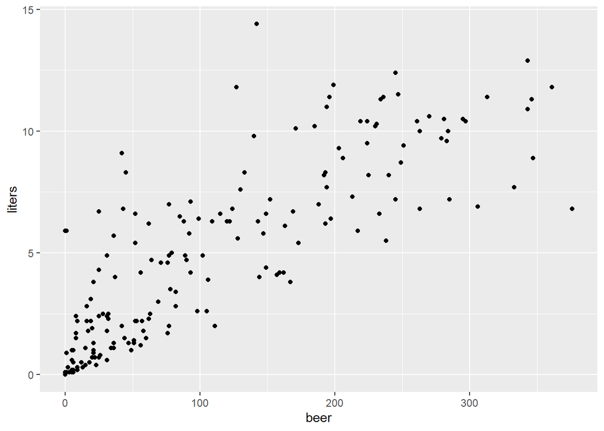

```r
ggplot(data = drinks, aes(x = beer, y = liters)) + geom_point()
```

Let’s make a bar chart with ggplot2 using drinks data with different y axe.

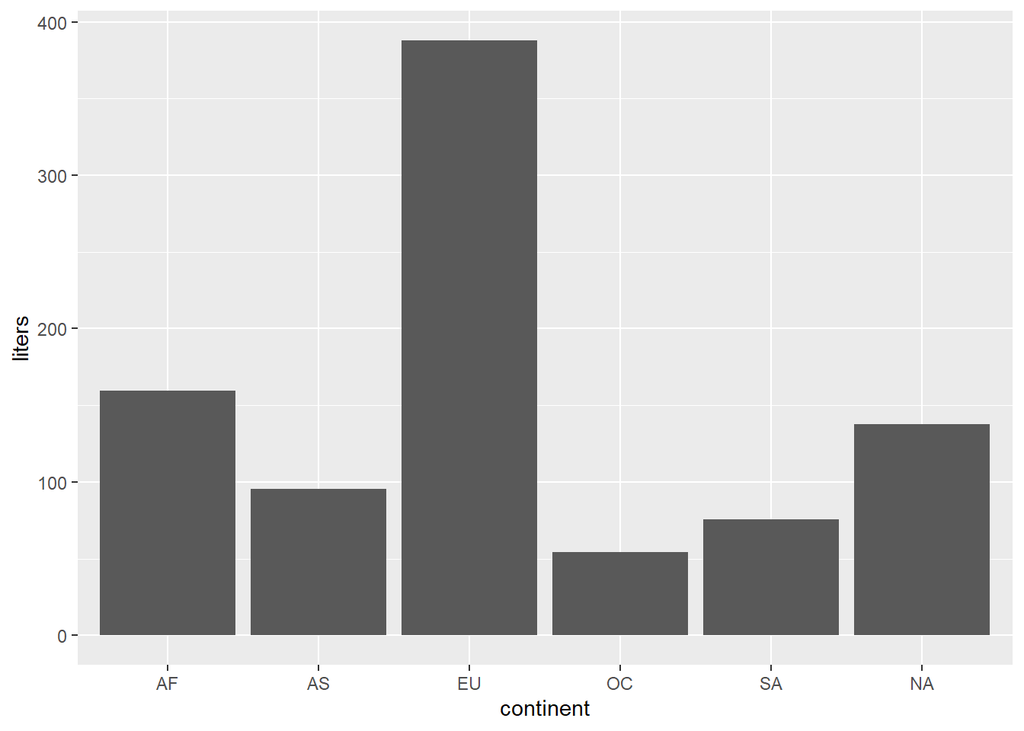

```r
ggplot(data = drinks, aes(x = continent,y=liters)) +
  geom_bar(stat = 'identity')
```

### **Challenge: Create a line plot of `RM` and `MEDV` in the housing data.**

- For `RM`, use a solid green line. For `MEDV`, use a blue dashed line.
- Change the style sheet to something you find

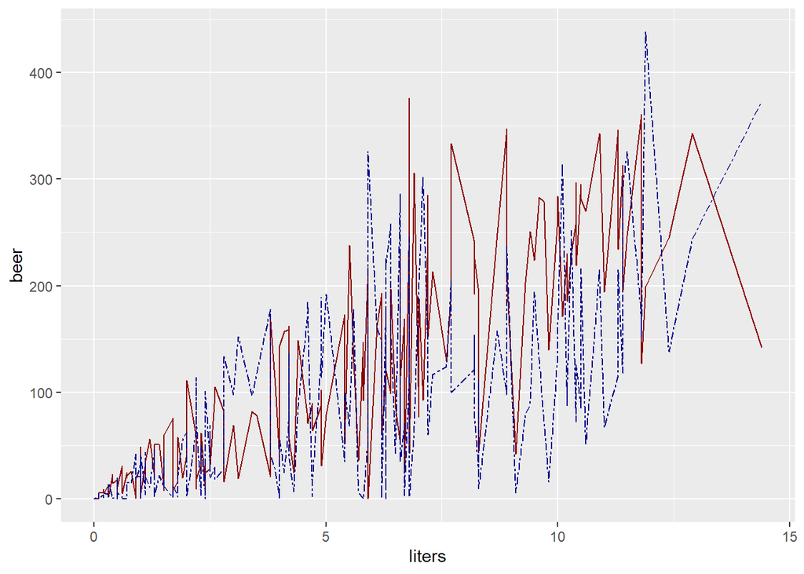

```r
ggplot(drinks, aes(x=liters)) +
  geom_line(aes(y = beer), color = "darkred") +
  geom_line(aes(y = spirit), color="darkblue", linetype="twodash")
```

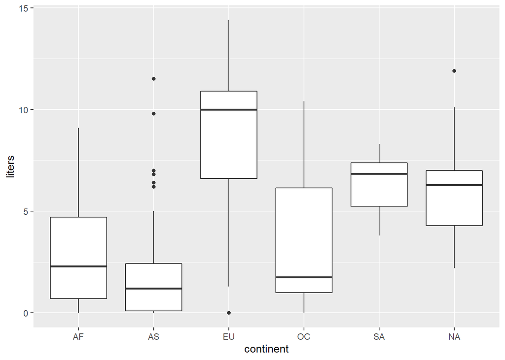

```r
ggplot(drinks, aes(continent, liters)) +geom_boxplot()
```

- Let’s make the chart a little bit fancier:

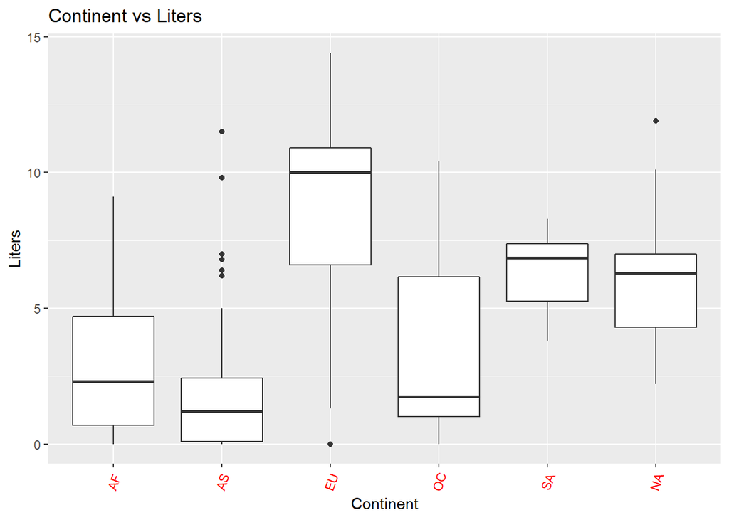

```r
ggplot(drinks, aes(continent, liters)) +geom_boxplot() +ggtitle("Box Plot") + theme(axis.text.x = element_text(angle = 70, vjust = 0.5, color = "red")) + xlab("Continent") + ylab("Liters") + ggtitle("Continent vs Liters")
```

## **Create histogram**

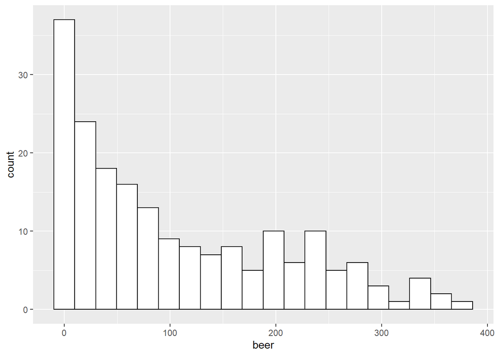

```r
ggplot(drinks, aes(x=beer)) + geom_histogram(bins = 20,color="black", fill="white")
```

- Histogram for different groups:

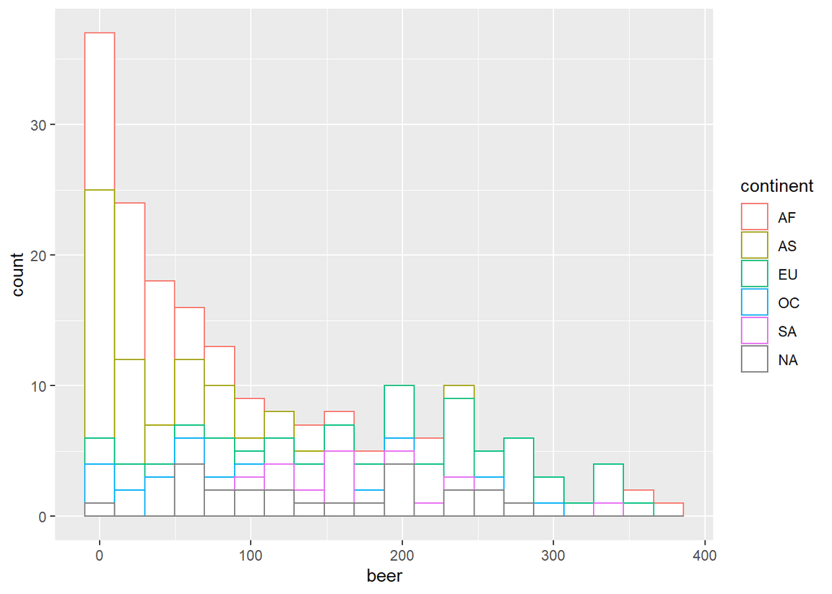

```r
# Change histogram plot line colors by groups
ggplot(drinks, aes(x=beer, color=continent)) +
  geom_histogram(fill="white",bins = 20)
```

```r
# Overlaid histograms
```

There are much more you can do! check [this](https://rstudio.com/wp-content/uploads/2016/11/ggplot2-cheatsheet-2.1.pdf) out

**Extra: Dot + Box Plot**

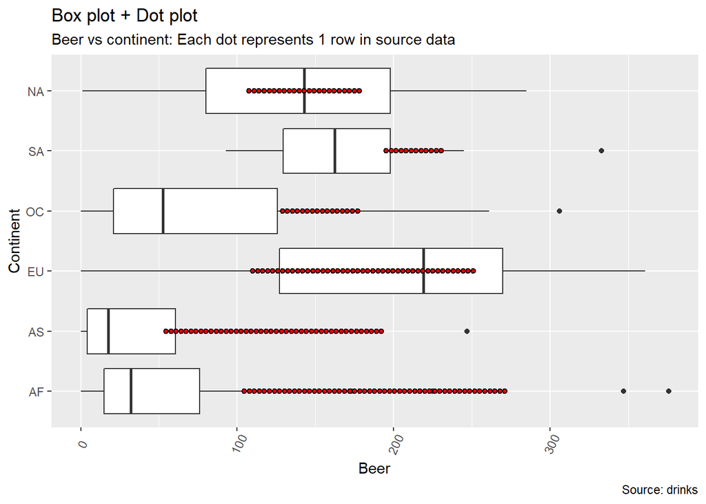

```r
library(ggplot2)

# plot
g <- ggplot(drinks, aes(beer, continent))
g + geom_boxplot() +
  geom_dotplot(binaxis='y',
               stackdir='center',
               dotsize = .5,
               fill="red") +
  theme(axis.text.x = element_text(angle=65, vjust=0.6)) +
  labs(title="Box plot + Dot plot",
       subtitle="Beer vs continent: Each dot represents 1 row in source data",
       caption="Source: drinks",
       x="Beer",
       y="Continent")
```

More charts: [Advanced ggplot2](http://r-statistics.co/Top50-Ggplot2-Visualizations-MasterList-R-Code.html#Tufte%20Boxplot)

# Predictive Analytics

## **Where Are We in the Data Science Workflow?**

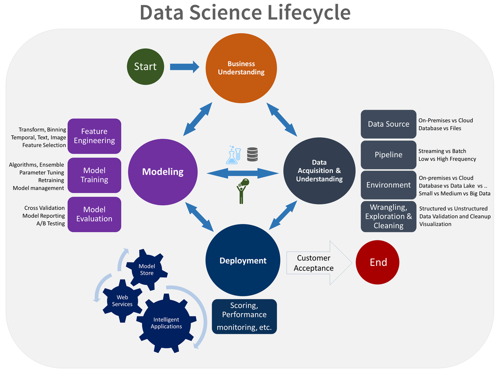

## Terminology

**Model**

- A simplified representation of reality created to serve a purpose
- When we say **model**, we mean it in the same sense that a toy car is a **model** of a real car. If we mainly care about appearance, the toy car model is an excellent model. However, the toy car fails to accurately represent other aspects of the car. For example, we cannot use a toy car to test how the actual car would perform in a collision.
- In data science, we might take a rich, complex person and model that person solely as a two-dimensional vector: *(age, smokes cigarettes)*. For example: (90,1), (28,0) , and (52,1), where 1 indicates “smokes cigarettes.” This model of a complex person obviously fails to account for many things. However, if we primarily care about modeling health risk, it might provide valuable insight.
- Now that we have superficially modeled a complex person, we might determine a formula that evaluates risk. For example, an older person tends to have worse health, as does a person who smokes. So, we might deem someone as having risk should `age + 50*smokes > 100`.
- This is a **mathematical model**, as we use math to assess risk. It could be mostly accurate. However, there are surely elderly people who smoke who are in excellent health.

### Input data terminology

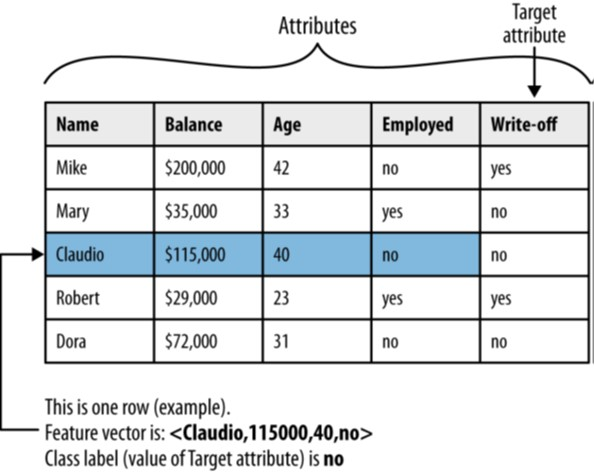

## Common Data Science Tasks

- **Classification** and class probability estimation
  - *How likely* is this consumer to respond to our campaign?
- **Regression**
  - *How much* will she use the service?
- **Similarity Matching**
  - Can we find consumers similar to my best customers?
- **Clustering**
  - Do my customers form natural groups?
- **Co-occurrence Grouping and Association Rules**
  - Also known as frequent itemset mining, association rule discovery, and market-basket analysis
  - What items are commonly purchased together?

[figure not shown]

## Training vs. Use of the Model

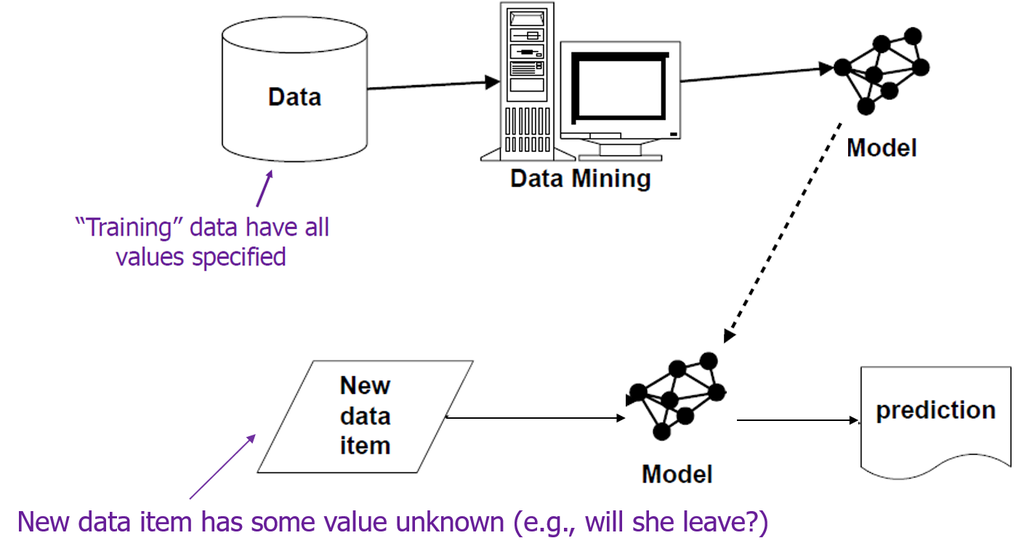

## **Linear Regression**

Input dataset:

```r
real_state <- read.csv("data/Real estate.csv")
head(real_state)
```

```
##   X1.transaction.date X2.house.age X3.distance.to.the.nearest.MRT.station X4.number.of.convenience.stores X5.latitude X6.longitude Y.house.price.of.unit.area
## 1            2013.417         16.9                              368.13630                               8    24.96750     121.5445                       42.3
## 2            2012.667          1.5                               23.38284                               7    24.96772     121.5410                       47.7
## 3            2013.417          4.5                             2275.87700                               3    24.96314     121.5115                       29.3
## 4            2013.417         10.5                              279.17260                               7    24.97528     121.5454                       51.6
## 5            2012.917         14.7                             1360.13900                               1    24.95204     121.5484                       24.6
## 6            2013.083         10.1                              279.17260                               7    24.97528     121.5454                       47.9
```

```r
str(real_state)
```

```
## 'data.frame':    396 obs. of  7 variables:
##  $ X1.transaction.date                   : num  2013 2013 2013 2013 2013 ...
##  $ X2.house.age                          : num  16.9 1.5 4.5 10.5 14.7 10.1 39.6 29.3 3.1 10.4 ...
##  $ X3.distance.to.the.nearest.MRT.station: num  368.1 23.4 2275.9 279.2 1360.1 ...
##  $ X4.number.of.convenience.stores       : int  8 7 3 7 1 7 4 2 5 5 ...
##  $ X5.latitude                           : num  25 25 25 25 25 ...
##  $ X6.longitude                          : num  122 122 122 122 122 ...
##  $ Y.house.price.of.unit.area            : num  42.3 47.7 29.3 51.6 24.6 47.9 38.8 27 56.2 33.6 ...
```

### **Make relation of two variables**

```r
formula = Y.house.price.of.unit.area~ X2.house.age
lm_1 <- lm(formula,data=real_state)
summary(lm_1)
```

```
##
## Call:
## lm(formula = formula, data = real_state)
##
## Residuals:
##     Min      1Q  Median      3Q     Max
## -30.941 -10.717   1.739   8.210  77.979
##
## Coefficients:
##              Estimate Std. Error t value Pr(>|t|)
## (Intercept)   42.1680     1.2388  34.041  < 2e-16 ***
## X2.house.age  -0.2451     0.0589  -4.161  3.9e-05 ***
## ---
## Signif. codes:  0 '***' 0.001 '**' 0.01 '*' 0.05 '.' 0.1 ' ' 1
##
## Residual standard error: 13.37 on 394 degrees of freedom
## Multiple R-squared:  0.04209,    Adjusted R-squared:  0.03966
## F-statistic: 17.31 on 1 and 394 DF,  p-value: 3.898e-05
```

### **Coefficients**

  **Practice:** Build a regression model to estimate the housing price based on the distance to nearest MRT station.

  ```r
  #write your code.
  ```

- When a regression takes into account two or more predictors to create the linear regression
  - It’s called multiple linear regression
  - price = a + age x *b1 + (number.of.convenience.stores)* x b2

    ```r
    formula2 =  Y.house.price.of.unit.area~ X2.house.age + X4.number.of.convenience.stores
    lm_2 <- lm(formula2,data=real_state)
    summary(lm_2)
    ```

    ```
    ##
    ## Call:
    ## lm(formula = formula2, data = real_state)
    ##
    ## Residuals:
    ##     Min      1Q  Median      3Q     Max
    ## -36.337  -7.163  -1.998   5.402  86.044
    ##
    ## Coefficients:
    ##                                 Estimate Std. Error t value Pr(>|t|)
    ## (Intercept)                     31.82119    1.20860  26.329  < 2e-16 ***
    ## X2.house.age                    -0.28614    0.04718  -6.065 3.11e-09 ***
    ## X4.number.of.convenience.stores  2.72504    0.18239  14.941  < 2e-16 ***
    ## ---
    ## Signif. codes:  0 '***' 0.001 '**' 0.01 '*' 0.05 '.' 0.1 ' ' 1
    ##
    ## Residual standard error: 10.69 on 393 degrees of freedom
    ## Multiple R-squared:  0.3891, Adjusted R-squared:  0.386
    ## F-statistic: 125.2 on 2 and 393 DF,  p-value: < 2.2e-16
    ```

    - Look at the summary and estimation of weights.
    - t-value: we want it to be far away from zero as this would indicate we could reject the null hypothesis (there is a relationship)
    - Another aspect to pay attention to your linear models is the p-value of the coefficients.
    - Probability of observing any value equal or larger than t
    - A small p-value indicates that it is unlikely we will observe a relationship between the predictor and response variables due to chance
    - A p-value indicates whether or not you can reject or accept a hypothesis
    - The hypothesis, in this case, is that the predictor is not meaningful for your model.
    - Three stars (or asterisks) represent a highly significant p-value
    - The p-value for convenience stores is < 2e-16. A very small value means that this attribute is probably an excellent addition to your model.
    - A standard way to test if the predictors are not meaningful is looking if the p-values smaller than **0.05**

      ```r
      #select attributes
      library(dplyr)
      dat <- select(real_state, X2.house.age
      , Y.house.price.of.unit.area)
      ```

### **Residuals**

    - A good way to test the quality of the fit of the model is to look at the residuals or the differences between the real values and the predicted values
    - Residuals are essentially the difference between the actual observed response values and the response values that the model predicted.
    - Degrees of freedom are the number of data points that went into the estimation of the parameters used after taking into account these parameters
    - The red vertical line from the straight line to the observed data value is the residual. The idea in here is that the sum of the residuals is approximately zero or as low as possible

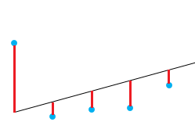

```r
summary(lm_1)
```

```
##
## Call:
## lm(formula = formula, data = real_state)
##
## Residuals:
##     Min      1Q  Median      3Q     Max
## -30.941 -10.717   1.739   8.210  77.979
##
## Coefficients:
##              Estimate Std. Error t value Pr(>|t|)
## (Intercept)   42.1680     1.2388  34.041  < 2e-16 ***
## X2.house.age  -0.2451     0.0589  -4.161  3.9e-05 ***
## ---
## Signif. codes:  0 '***' 0.001 '**' 0.01 '*' 0.05 '.' 0.1 ' ' 1
##
## Residual standard error: 13.37 on 394 degrees of freedom
## Multiple R-squared:  0.04209,    Adjusted R-squared:  0.03966
## F-statistic: 17.31 on 1 and 394 DF,  p-value: 3.898e-05
```

```r
summary(lm_2)
```

```
##
## Call:
## lm(formula = formula2, data = real_state)
##
## Residuals:
##     Min      1Q  Median      3Q     Max
## -36.337  -7.163  -1.998   5.402  86.044
##
## Coefficients:
##                                 Estimate Std. Error t value Pr(>|t|)
## (Intercept)                     31.82119    1.20860  26.329  < 2e-16 ***
## X2.house.age                    -0.28614    0.04718  -6.065 3.11e-09 ***
## X4.number.of.convenience.stores  2.72504    0.18239  14.941  < 2e-16 ***
## ---
## Signif. codes:  0 '***' 0.001 '**' 0.01 '*' 0.05 '.' 0.1 ' ' 1
##
## Residual standard error: 10.69 on 393 degrees of freedom
## Multiple R-squared:  0.3891, Adjusted R-squared:  0.386
## F-statistic: 125.2 on 2 and 393 DF,  p-value: < 2.2e-16
```